# Churn Analytics in E-commerce

## Overview

**Definition**

Customer churn rate is the percentage of customers who stop doing business with an organization over a period of time. Businesses can evaluate this metric annually, monthly, weekly, or daily.

**Importance of analyzing customer churn**

Churn impacts nearly every aspect of a company, from the product and revenue to customer satisfaction and loyalty. Understanding this crucial metric can lead to several benefits:

- Improved customer retention: Oftentimes, when you reduce churn rate, you improve customer retention. An increase in customer retention leads to increased profitability and more long-term relationships with your customers.
- Enhanced outreach: You can use churn rate to help evaluate the impact of outreach campaigns and determine if your messaging resonates with your audience. A lack of engagement or increased churn could indicate a shift in campaign strategy is needed.
- Improved product: When unveiling new product features, keep an eye on the churn rate to determine how your audience feels about the changes. A lower churn could indicate your audience appreciates the new features.
- Reduced costs: It’s common knowledge that acquiring a new customer costs more than retaining an existing one. So, companies that lose customers aren’t just losing the revenue from those individuals—they’re also burdened with the cost of finding new ones.

Being fluent in your customer churn rate is the first step to understanding your customer base, improving your business, and creating long-term consumer relationships.

Let's dig dive into project details

## Understanding the dataset

```python
pip install xgboost
```

```python
import numpy as np
import pandas as pd
import seaborn as sns
import matplotlib.pyplot as plt
import sklearn
from sklearn.preprocessing import StandardScaler
from lightgbm import LGBMClassifier
from sklearn.ensemble import RandomForestClassifier, GradientBoostingClassifier, VotingClassifier, AdaBoostClassifier
from sklearn.linear_model import LogisticRegression
from sklearn.model_selection import cross_validate, GridSearchCV
from sklearn.neighbors import KNeighborsClassifier
from sklearn.preprocessing import StandardScaler
from sklearn.svm import SVC
from sklearn.tree import DecisionTreeClassifier
from xgboost import XGBClassifier
from sklearn.preprocessing import LabelEncoder
from sklearn.model_selection import train_test_split, cross_validate, GridSearchCV
import warnings
warnings.simplefilter(action="ignore")
pd.set_option('display.max_columns', None)
pd.set_option('display.width', 170)
pd.set_option('display.max_rows', None)
pd.set_option('display.float_format', lambda x: '%.3f' % x)
```

```python
df = pd.read_csv("E_Commerce.csv")
```

```python
print("------------------- Shape -------------------")
print(df.shape)
print("------------------- Types -------------------")
print(df.dtypes)
```

```
------------------- Shape -------------------
(5630, 20)
------------------- Types -------------------
CustomerID                       int64
Churn                            int64
Tenure                         float64
PreferredLoginDevice            object
CityTier                         int64
WarehouseToHome                float64
PreferredPaymentMode            object
Gender                          object
HourSpendOnApp                 float64
NumberOfDeviceRegistered         int64
PreferedOrderCat                object
SatisfactionScore                int64
MaritalStatus                   object
NumberOfAddress                  int64
Complain                         int64
OrderAmountHikeFromlastYear    float64
CouponUsed                     float64
OrderCount                     float64
DaySinceLastOrder              float64
CashbackAmount                   int64
dtype: object
```

```python
df.head(10)
```

|  | CustomerID | Churn | Tenure | PreferredLoginDevice | CityTier | WarehouseToHome | PreferredPaymentMode | Gender | HourSpendOnApp | NumberOfDeviceRegistered | PreferedOrderCat | SatisfactionScore | MaritalStatus | NumberOfAddress | Complain | OrderAmountHikeFromlastYear | CouponUsed | OrderCount | DaySinceLastOrder | CashbackAmount |
| --- | --- | --- | --- | --- | --- | --- | --- | --- | --- | --- | --- | --- | --- | --- | --- | --- | --- | --- | --- | --- |
| 0 | 50001 | 1 | 4.000 | Mobile Phone | 3 | 6.000 | Debit Card | Female | 3.000 | 3 | Laptop & Accessory | 2 | Single | 9 | 1 | 11.000 | 1.000 | 1.000 | 5.000 | 160 |
| 1 | 50002 | 1 | NaN | Phone | 1 | 8.000 | UPI | Male | 3.000 | 4 | Mobile | 3 | Single | 7 | 1 | 15.000 | 0.000 | 1.000 | 0.000 | 121 |
| 2 | 50003 | 1 | NaN | Phone | 1 | 30.000 | Debit Card | Male | 2.000 | 4 | Mobile | 3 | Single | 6 | 1 | 14.000 | 0.000 | 1.000 | 3.000 | 120 |
| 3 | 50004 | 1 | 0.000 | Phone | 3 | 15.000 | Debit Card | Male | 2.000 | 4 | Laptop & Accessory | 5 | Single | 8 | 0 | 23.000 | 0.000 | 1.000 | 3.000 | 134 |
| 4 | 50005 | 1 | 0.000 | Phone | 1 | 12.000 | CC | Male | NaN | 3 | Mobile | 5 | Single | 3 | 0 | 11.000 | 1.000 | 1.000 | 3.000 | 130 |
| 5 | 50006 | 1 | 0.000 | Computer | 1 | 22.000 | Debit Card | Female | 3.000 | 5 | Mobile Phone | 5 | Single | 2 | 1 | 22.000 | 4.000 | 6.000 | 7.000 | 139 |
| 6 | 50007 | 1 | NaN | Phone | 3 | 11.000 | Cash on Delivery | Male | 2.000 | 3 | Laptop & Accessory | 2 | Divorced | 4 | 0 | 14.000 | 0.000 | 1.000 | 0.000 | 121 |
| 7 | 50008 | 1 | NaN | Phone | 1 | 6.000 | CC | Male | 3.000 | 3 | Mobile | 2 | Divorced | 3 | 1 | 16.000 | 2.000 | 2.000 | 0.000 | 123 |
| 8 | 50009 | 1 | 13.000 | Phone | 3 | 9.000 | E wallet | Male | NaN | 4 | Mobile | 3 | Divorced | 2 | 1 | 14.000 | 0.000 | 1.000 | 2.000 | 127 |
| 9 | 50010 | 1 | NaN | Phone | 1 | 31.000 | Debit Card | Male | 2.000 | 5 | Mobile | 3 | Single | 2 | 0 | 12.000 | 1.000 | 1.000 | 1.000 | 123 |

```python
df.describe().T
```

|  | count | mean | std | min | 25% | 50% | 75% | max |
| --- | --- | --- | --- | --- | --- | --- | --- | --- |
| CustomerID | 5630.000 | 52815.500 | 1625.385 | 50001.000 | 51408.250 | 52815.500 | 54222.750 | 55630.000 |
| Churn | 5630.000 | 0.168 | 0.374 | 0.000 | 0.000 | 0.000 | 0.000 | 1.000 |
| Tenure | 5366.000 | 10.190 | 8.557 | 0.000 | 2.000 | 9.000 | 16.000 | 61.000 |
| CityTier | 5630.000 | 1.655 | 0.915 | 1.000 | 1.000 | 1.000 | 3.000 | 3.000 |
| WarehouseToHome | 5379.000 | 15.640 | 8.531 | 5.000 | 9.000 | 14.000 | 20.000 | 127.000 |
| HourSpendOnApp | 5375.000 | 2.932 | 0.722 | 0.000 | 2.000 | 3.000 | 3.000 | 5.000 |
| NumberOfDeviceRegistered | 5630.000 | 3.689 | 1.024 | 1.000 | 3.000 | 4.000 | 4.000 | 6.000 |
| SatisfactionScore | 5630.000 | 3.067 | 1.380 | 1.000 | 2.000 | 3.000 | 4.000 | 5.000 |
| NumberOfAddress | 5630.000 | 4.214 | 2.584 | 1.000 | 2.000 | 3.000 | 6.000 | 22.000 |
| Complain | 5630.000 | 0.285 | 0.451 | 0.000 | 0.000 | 0.000 | 1.000 | 1.000 |
| OrderAmountHikeFromlastYear | 5365.000 | 15.708 | 3.675 | 11.000 | 13.000 | 15.000 | 18.000 | 26.000 |
| CouponUsed | 5374.000 | 1.751 | 1.895 | 0.000 | 1.000 | 1.000 | 2.000 | 16.000 |
| OrderCount | 5372.000 | 3.008 | 2.940 | 1.000 | 1.000 | 2.000 | 3.000 | 16.000 |
| DaySinceLastOrder | 5323.000 | 4.543 | 3.654 | 0.000 | 2.000 | 3.000 | 7.000 | 46.000 |
| CashbackAmount | 5630.000 | 177.221 | 49.194 | 0.000 | 146.000 | 163.000 | 196.000 | 325.000 |

```python
df.describe(include='O').T
```

|  | count | unique | top | freq |
| --- | --- | --- | --- | --- |
| PreferredLoginDevice | 5630 | 3 | Mobile Phone | 2765 |
| PreferredPaymentMode | 5630 | 7 | Debit Card | 2314 |
| Gender | 5630 | 2 | Male | 3384 |
| PreferedOrderCat | 5630 | 6 | Laptop & Accessory | 2050 |
| MaritalStatus | 5630 | 3 | Married | 2986 |

```python
df.info()
```

```
<class 'pandas.core.frame.DataFrame'>
RangeIndex: 5630 entries, 0 to 5629
Data columns (total 20 columns):
 #   Column                       Non-Null Count  Dtype
---  ------                       --------------  -----
 0   CustomerID                   5630 non-null   int64
 1   Churn                        5630 non-null   int64
 2   Tenure                       5366 non-null   float64
 3   PreferredLoginDevice         5630 non-null   object
 4   CityTier                     5630 non-null   int64
 5   WarehouseToHome              5379 non-null   float64
 6   PreferredPaymentMode         5630 non-null   object
 7   Gender                       5630 non-null   object
 8   HourSpendOnApp               5375 non-null   float64
 9   NumberOfDeviceRegistered     5630 non-null   int64
 10  PreferedOrderCat             5630 non-null   object
 11  SatisfactionScore            5630 non-null   int64
 12  MaritalStatus                5630 non-null   object
 13  NumberOfAddress              5630 non-null   int64
 14  Complain                     5630 non-null   int64
 15  OrderAmountHikeFromlastYear  5365 non-null   float64
 16  CouponUsed                   5374 non-null   float64
 17  OrderCount                   5372 non-null   float64
 18  DaySinceLastOrder            5323 non-null   float64
 19  CashbackAmount               5630 non-null   int64
dtypes: float64(7), int64(8), object(5)
memory usage: 879.8+ KB
```

```python
df.isnull().sum().sort_values(ascending=0)
```

```
DaySinceLastOrder              307
OrderAmountHikeFromlastYear    265
Tenure                         264
OrderCount                     258
CouponUsed                     256
HourSpendOnApp                 255
WarehouseToHome                251
CustomerID                       0
MaritalStatus                    0
Complain                         0
NumberOfAddress                  0
PreferedOrderCat                 0
SatisfactionScore                0
Churn                            0
NumberOfDeviceRegistered         0
Gender                           0
PreferredPaymentMode             0
CityTier                         0
PreferredLoginDevice             0
CashbackAmount                   0
dtype: int64
```

**Comment:**

Seeing we got missing values in a couple of columns. Must have the missing data imputation after we have been through the EDA section.

## Exploratory Data Analysis

### Univariate Analysis

If carefully look at the data type of some columns like **Churn**, **HourSpendOnApp**, **SatisfactionScore**, etc., which have data types(int64, float64) as a numerical variable, but they actually are categorical variables.

Therefore, we need a function to classify columns that

- data type as categoric but they actually are numerical variables, which are subject to be categoric types but over 20 unique values
- data type as numeric but they are actually categorical variables, which are subject to be numeric types but less than 10 unique values

```python
def grab_col_names(df, cat_th=10, car_th=20):
      # cat_cols, cat_but_car
    cat_cols = [col for col in df.columns if df[col].dtypes == "O"]
    num_but_cat = [col for col in df.columns if df[col].nunique() < cat_th and df[col].dtypes != "O"]
    cat_but_car = [col for col in df.columns if df[col].nunique() > car_th and df[col].dtypes == "O"]
    cat_cols = cat_cols + num_but_cat
    cat_cols = [col for col in cat_cols if col not in cat_but_car]

    # num_cols
    num_cols = [col for col in df.columns if df[col].dtypes != "O"]
    num_cols = [col for col in num_cols if col not in num_but_cat]

    print(f"Observations: {df.shape[0]}")
    print(f"Variables: {df.shape[1]}")
    print(f'cat_cols: {len(cat_cols)}')
    print(f'num_cols: {len(num_cols)}')
    print(f'cat_but_car: {len(cat_but_car)}')
    print(f'num_but_cat: {len(num_but_cat)}')

    return cat_cols, num_cols, cat_but_car

cat_cols, num_cols, cat_but_car = grab_col_names(df)
```

```
Observations: 5630
Variables: 20
cat_cols: 11
num_cols: 9
cat_but_car: 0
num_but_cat: 6
```

So we found out that 6 columns are under numeric types but actually are categorical variables, which are:

- `Churn`
- `CityTier`
- `HourSpendOnApp`
- `NumberOfDeviceRegistered`
- `SatisfactionScore`
- `Complain`

#### Categorical variables

Let's have a look throughout the term of foundation for **each categorical variable**.

```python
cat_cols
```

```
['PreferredLoginDevice',
 'PreferredPaymentMode',
 'Gender',
 'PreferedOrderCat',
 'MaritalStatus',
 'Churn',
 'CityTier',
 'HourSpendOnApp',
 'NumberOfDeviceRegistered',
 'SatisfactionScore',
 'Complain']
```

```
Summary for PreferredLoginDevice:
  PreferredLoginDevice  Count  Ratio
0         Mobile Phone   2765 49.112
1             Computer   1634 29.023
2                Phone   1231 21.865
---------------------------------------------------------------
Summary for PreferredPaymentMode:
  PreferredPaymentMode  Count  Ratio
0           Debit Card   2314 41.101
1          Credit Card   1501 26.661
2             E wallet    614 10.906
3                  UPI    414  7.353
4                  COD    365  6.483
5                   CC    273  4.849
6     Cash on Delivery    149  2.647
---------------------------------------------------------------
Summary for Gender:
   Gender  Count  Ratio
0    Male   3384 60.107
1  Female   2246 39.893
---------------------------------------------------------------
Summary for PreferedOrderCat:
     PreferedOrderCat  Count  Ratio
0  Laptop & Accessory   2050 36.412
1        Mobile Phone   1271 22.575
2             Fashion    826 14.671
3              Mobile    809 14.369
4             Grocery    410  7.282
5              Others    264  4.689
---------------------------------------------------------------
Summary for MaritalStatus:
  MaritalStatus  Count  Ratio
0       Married   2986 53.037
1        Single   1796 31.901
2      Divorced    848 15.062
---------------------------------------------------------------
Summary for Churn:
   Churn  Count  Ratio
0      0   4682 83.162
1      1    948 16.838
```

[output cut: 23 more lines]

```
5                         6    162  2.877
---------------------------------------------------------------
Summary for SatisfactionScore:
   SatisfactionScore  Count  Ratio
0                  3   1698 30.160
1                  1   1164 20.675
2                  5   1108 19.680
3                  4   1074 19.076
4                  2    586 10.409
---------------------------------------------------------------
Summary for Complain:
   Complain  Count  Ratio
0         0   4026 71.510
1         1   1604 28.490
---------------------------------------------------------------
```

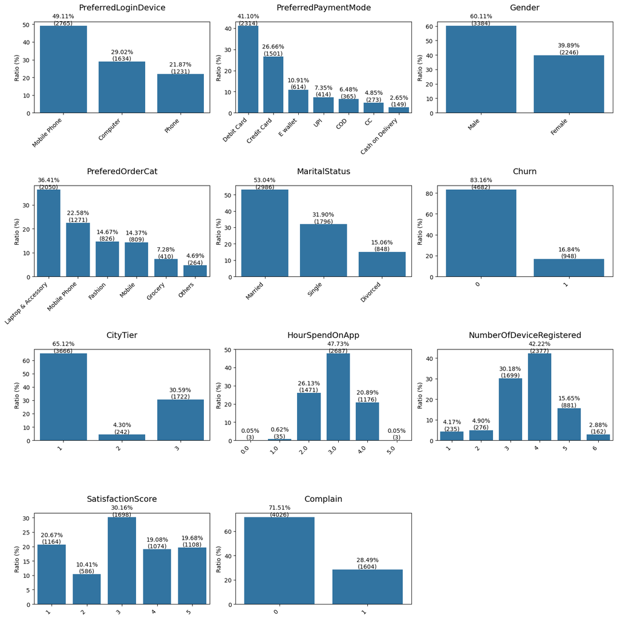

```python
def cat_summary(dataframe, col_name):
    summary = pd.DataFrame({
        col_name: dataframe[col_name].value_counts().index,
        "Count": dataframe[col_name].value_counts().values,
        "Ratio": 100 * dataframe[col_name].value_counts().values / len(dataframe)
    })
    summary = summary.sort_values("Ratio", ascending=False).reset_index(drop=True)
    return summary

def plot_cat_summary(summaries, ncols=3, figsize=(15, 15)):
    nrows = (len(summaries) + ncols - 1) // ncols
    fig, axes = plt.subplots(nrows, ncols, figsize=figsize)
    axes = axes.flatten()

    for i, (col, summary) in enumerate(summaries.items()):
        ax = axes[i]
        bars = sns.barplot(x=col, y="Ratio", data=summary, ax=ax)
        ax.set_title(col, fontsize=14, pad=20)
        ax.set_xlabel("")
        ax.set_ylabel("Ratio (%)")
        ax.set_xticklabels(ax.get_xticklabels(), rotation=45, ha='right')

        # Add labels on top of each bar
        for bar in bars.patches:
            height = bar.get_height()
            width = bar.get_width()
            x = bar.get_x()
            category = summary[col][summary['Ratio'] == height].values[0]
            ratio = height
            count = summary[summary[col] == category]['Count'].values[0]
            ax.text(x + width/2., height,
                    f'{ratio:.2f}%\n({count})',
                    ha='center', va='bottom', rotation=0)

    for j in range(i+1, len(axes)):
        fig.delaxes(axes[j])

    plt.tight_layout()
    plt.show()

# Assuming df and cat_cols are already defined
summaries = {}
for col in cat_cols:
    summary = cat_summary(df, col)
    summaries[col] = summary
    print(f"Summary for {col}:")
    print(summary)
    print("---------------------------------------------------------------")

# Plot the summaries
plot_cat_summary(summaries)
```

**Comment:**

After having some calculations and visualizations of the output, we did not receive any anomalies in the distribution of categorical variables. Expect some slightly unusual and noteworthy points in HourSpendOnApp, which is 95% of customers spending about 2-4 hours to decide for orders. Kinda weird a little, but it can be explained by nearly 60% of **PreferedOrderCat** including Laptop & Accessory, Mobile Phone as the chart shows, customers need more time to research products, especially Laptop or Mobile Phone. It does make sense but to dive further, less than 1% of customers who spend 0-2 hours to order on the platform is something unusual.

#### Numerical variables

Let's have a look throughout the term of foundation for **each numerical variable**.

```python
num_cols
```

```
['CustomerID',
 'Tenure',
 'WarehouseToHome',
 'NumberOfAddress',
 'OrderAmountHikeFromlastYear',
 'CouponUsed',
 'OrderCount',
 'DaySinceLastOrder',
 'CashbackAmount']
```

```python
quantiles = [0.05, 0.10, 0.20, 0.30, 0.40, 0.50, 0.60, 0.70, 0.80, 0.90, 0.95, 0.99]
df[num_cols].describe(quantiles)
```

|  | CustomerID | Tenure | WarehouseToHome | NumberOfAddress | OrderAmountHikeFromlastYear | CouponUsed | OrderCount | DaySinceLastOrder | CashbackAmount |
| --- | --- | --- | --- | --- | --- | --- | --- | --- | --- |
| count | 5630.000 | 5366.000 | 5379.000 | 5630.000 | 5365.000 | 5374.000 | 5372.000 | 5323.000 | 5630.000 |
| mean | 52815.500 | 10.190 | 15.640 | 4.214 | 15.708 | 1.751 | 3.008 | 4.543 | 177.221 |
| std | 1625.385 | 8.557 | 8.531 | 2.584 | 3.675 | 1.895 | 2.940 | 3.654 | 49.194 |
| min | 50001.000 | 0.000 | 5.000 | 1.000 | 11.000 | 0.000 | 1.000 | 0.000 | 0.000 |
| 5% | 50282.450 | 0.000 | 6.000 | 1.000 | 11.000 | 0.000 | 1.000 | 0.000 | 123.000 |
| 10% | 50563.900 | 1.000 | 7.000 | 2.000 | 12.000 | 0.000 | 1.000 | 1.000 | 127.000 |
| 20% | 51126.800 | 1.000 | 8.000 | 2.000 | 12.000 | 1.000 | 1.000 | 1.000 | 141.000 |
| 30% | 51689.700 | 4.000 | 9.000 | 2.000 | 13.000 | 1.000 | 1.000 | 2.000 | 148.000 |
| 40% | 52252.600 | 6.000 | 11.000 | 3.000 | 14.000 | 1.000 | 2.000 | 3.000 | 154.000 |
| 50% | 52815.500 | 9.000 | 14.000 | 3.000 | 15.000 | 1.000 | 2.000 | 3.000 | 163.000 |
| 60% | 53378.400 | 11.000 | 15.000 | 4.000 | 16.000 | 2.000 | 2.000 | 4.000 | 173.000 |
| 70% | 53941.300 | 14.000 | 17.000 | 5.000 | 17.000 | 2.000 | 2.000 | 7.000 | 187.000 |
| 80% | 54504.200 | 18.000 | 23.000 | 6.000 | 19.000 | 2.000 | 4.000 | 8.000 | 209.000 |
| 90% | 55067.100 | 23.000 | 30.000 | 8.000 | 21.000 | 4.000 | 7.000 | 9.000 | 260.000 |
| 95% | 55348.550 | 27.000 | 33.000 | 10.000 | 23.000 | 6.000 | 9.000 | 11.000 | 292.000 |
| 99% | 55573.710 | 30.000 | 35.000 | 11.000 | 25.000 | 9.000 | 15.000 | 15.000 | 318.710 |
| max | 55630.000 | 61.000 | 127.000 | 22.000 | 26.000 | 16.000 | 16.000 | 46.000 | 325.000 |

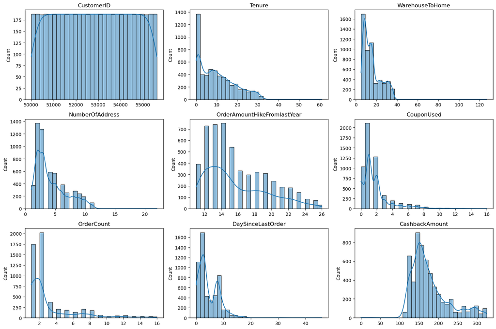

```python
def plot_summary(dataframe, numerical_cols, figsize=(15, 10), bins=30):
    # Calculate the number of rows and columns for the subplot grid
    n_cols = 3
    n_rows = (len(numerical_cols) - 1) // n_cols + 1

    # Create the subplot grid
    fig, axes = plt.subplots(n_rows, n_cols, figsize=figsize)
    axes = axes.flatten()  # Flatten the 2D array of axes to 1D for easy indexing

    for i, col in enumerate(numerical_cols):
        ax = axes[i]
        sns.histplot(data=dataframe, x=col, kde=True, ax=ax, bins=bins)
        ax.set_title(col)
        ax.set_xlabel('')

    # Remove any unused subplots
    for j in range(i+1, len(axes)):
        fig.delaxes(axes[j])

    plt.tight_layout()
    plt.show()

# Assuming df and num_cols are already defined
plot_summary(df, num_cols)
```

```python
def target_summary_with_num(dataframe, target, numerical_cols):
    return dataframe.groupby(target)[numerical_cols].mean()

result = target_summary_with_num(df, "Churn", num_cols)
result.round(2)
```

| Churn | CustomerID | Tenure | WarehouseToHome | NumberOfAddress | OrderAmountHikeFromlastYear | CouponUsed | OrderCount | DaySinceLastOrder | CashbackAmount |
| --- | --- | --- | --- | --- | --- | --- | --- | --- | --- |
| 0 | 52829.460 | 11.500 | 15.350 | 4.160 | 15.720 | 1.760 | 3.050 | 4.810 | 180.630 |
| 1 | 52746.580 | 3.380 | 17.130 | 4.470 | 15.630 | 1.720 | 2.820 | 3.240 | 160.370 |

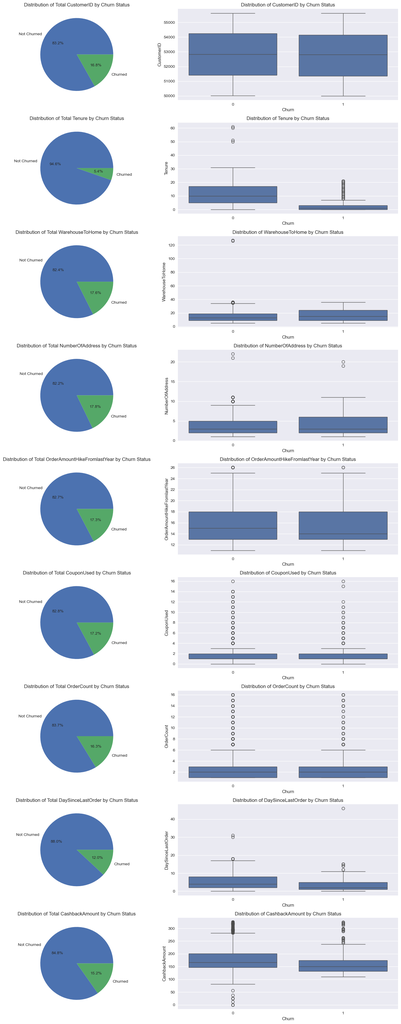

```python
def target_summary_with_num(dataframe, target, numerical_cols):
    return dataframe.groupby(target)[numerical_cols].mean()

# Calculate the summary statistics
result = target_summary_with_num(df, "Churn", num_cols)

# Set up the plotting style
plt.style.use('seaborn-v0_8')

# Create subplots
fig, axs = plt.subplots(len(num_cols), 2, figsize=(15,35))

# Ensure axs is always 2D
if len(num_cols) == 1:
    axs = axs.reshape(1, -1)

# Plot each numerical variable
for i, col in enumerate(num_cols):
    # Pie chart
    churned = df[df['Churn'] == 1][col].sum()
    not_churned = df[df['Churn'] == 0][col].sum()
    axs[i, 0].pie([not_churned, churned], labels=['Not Churned', 'Churned'], autopct='%1.1f%%')
    axs[i, 0].set_title(f'Distribution of Total {col} by Churn Status')

    # Box plot
    sns.boxplot(x='Churn', y=col, data=df, ax=axs[i, 1])
    axs[i, 1].set_title(f'Distribution of {col} by Churn Status')
    axs[i, 1].set_xlabel('Churn')
    axs[i, 1].set_ylabel(col)

# Adjust layout and show plot
plt.tight_layout()
plt.show()
```

**Comment:**

The distribution of the number of Churn on Numerical Variables is completely normal despite the large outliers on some variables. Hence, we need the outlier treatment, which is progress in **Data processing and Feature Engineering**

### Bivariate Analysis

We do bivariate analysis for checking the distribution and correlation of both numerical and categorical variables to the target variable `Churn`.

```
PreferredLoginDevice
                      CHURN_SUM  Count  Ratio
PreferredLoginDevice
Computer                    324   1634 29.020
Mobile Phone                348   2765 49.110
Phone                       276   1231 21.870


PreferredPaymentMode
                      CHURN_SUM  Count  Ratio
PreferredPaymentMode
CC                           59    273  4.850
COD                         105    365  6.480
Cash on Delivery             23    149  2.650
Credit Card                 193   1501 26.660
Debit Card                  356   2314 41.100
E wallet                    140    614 10.910
UPI                          72    414  7.350
```

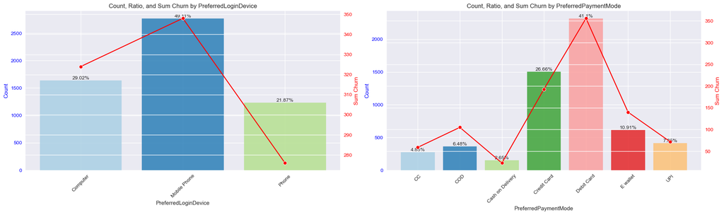

```
Gender
        CHURN_SUM  Count  Ratio
Gender
Female        348   2246 39.890
Male          600   3384 60.110


PreferedOrderCat
                    CHURN_SUM  Count  Ratio
PreferedOrderCat
Fashion                   128    826 14.670
Grocery                    20    410  7.280
Laptop & Accessory        210   2050 36.410
Mobile                    220    809 14.370
Mobile Phone              350   1271 22.580
Others                     20    264  4.690
```

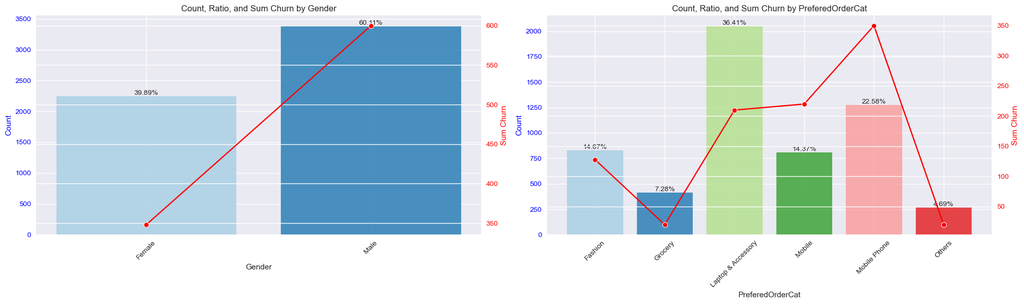

```
MaritalStatus
               CHURN_SUM  Count  Ratio
MaritalStatus
Divorced             124    848 15.060
Married              344   2986 53.040
Single               480   1796 31.900


Churn
       CHURN_SUM  Count  Ratio
Churn
0              0   4682 83.160
1            948    948 16.840
```

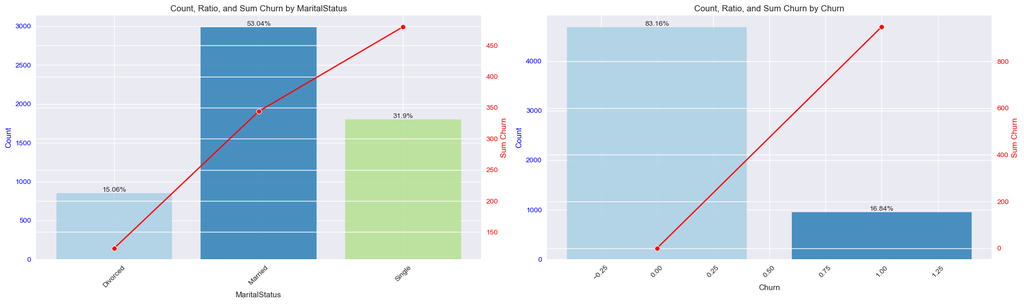

```
CityTier
          CHURN_SUM  Count  Ratio
CityTier
1               532   3666 65.120
2                48    242  4.300
3               368   1722 30.590


HourSpendOnApp
                CHURN_SUM  Count  Ratio
HourSpendOnApp
0.000                   0      3  0.050
1.000                   0     35  0.620
2.000                 232   1471 26.130
3.000                 460   2687 47.730
4.000                 198   1176 20.890
5.000                   0      3  0.050
```

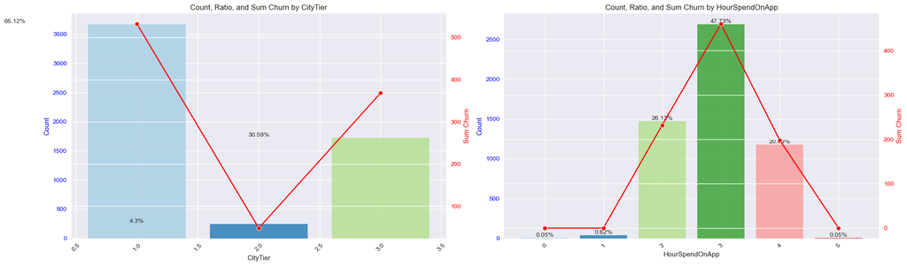

```
NumberOfDeviceRegistered
                          CHURN_SUM  Count  Ratio
NumberOfDeviceRegistered
1                                22    235  4.170
2                                26    276  4.900
3                               254   1699 30.180
4                               392   2377 42.220
5                               198    881 15.650
6                                56    162  2.880


SatisfactionScore
                   CHURN_SUM  Count  Ratio
SatisfactionScore
1                        134   1164 20.670
2                         74    586 10.410
3                        292   1698 30.160
4                        184   1074 19.080
5                        264   1108 19.680
```

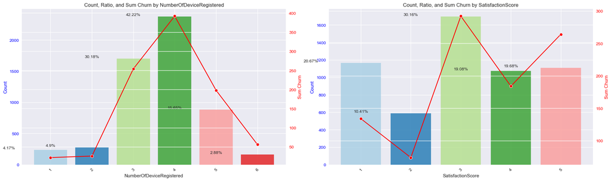

```
Complain
          CHURN_SUM  Count  Ratio
Complain
0               440   4026 71.510
1               508   1604 28.490
```

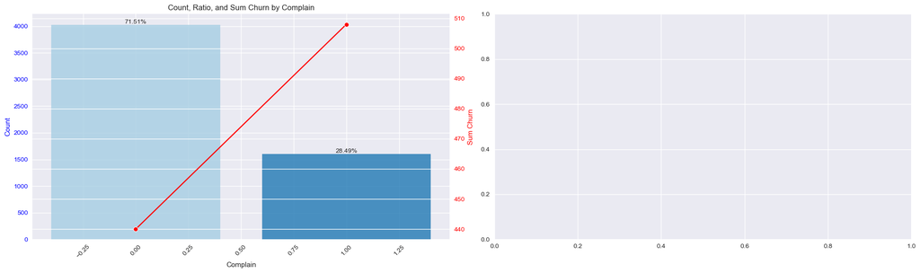

```python
def target_summary_with_cat(dataframe, target, categorical_cols):
    fig, axes = plt.subplots(1, 2, figsize=(20, 6))

    # Define a color palette
    color_palette = sns.color_palette("Paired", 8)  # Adjust the number of colors as needed

    for i, categorical_col in enumerate(categorical_cols):
        summary = pd.DataFrame({
            "CHURN_SUM": dataframe.groupby(categorical_col)[target].sum(),
            "Count": dataframe[categorical_col].value_counts(),
            "Ratio": (100 * dataframe[categorical_col].value_counts() / len(dataframe)).round(2)
        }).sort_index()

        print(categorical_col)
        print(summary, end="\n\n\n")

        ax1 = axes[i]

        # Bar plot for Count with different colors
        bars = ax1.bar(summary.index, summary['Count'], alpha=0.8)
        for j, bar in enumerate(bars):
            bar.set_color(color_palette[j % len(color_palette)])

        ax1.set_xlabel(categorical_col)
        ax1.set_ylabel('Count', color='blue')
        ax1.tick_params(axis='x', rotation=45)
        ax1.tick_params(axis='y', labelcolor='blue')

        # Add Ratio labels on top of the Count bars
        for j, v in enumerate(summary['Count']):
            ax1.text(j, v, f"{summary['Ratio'].iloc[j]}%", ha='center', va='bottom')

        # Create a twin axis for CHURN_SUM
        ax2 = ax1.twinx()

        # Line plot for CHURN_SUM
        sns.lineplot(x=summary.index, y='CHURN_SUM', data=summary, ax=ax2, color='red', marker='o')
        ax2.set_ylabel(f'Sum {target}', color='red')
        ax2.tick_params(axis='y', labelcolor='red')

        ax1.set_title(f'Count, Ratio, and Sum {target} by {categorical_col}')

    plt.tight_layout()
    plt.show()

for i in range(0, len(cat_cols), 2):
    cols_to_plot = cat_cols[i:i+2]
    target_summary_with_cat(df, "Churn", cols_to_plot)
```

```python
df[num_cols].corr()
```

|  | CustomerID | Tenure | WarehouseToHome | NumberOfAddress | OrderAmountHikeFromlastYear | CouponUsed | OrderCount | DaySinceLastOrder | CashbackAmount |
| --- | --- | --- | --- | --- | --- | --- | --- | --- | --- |
| CustomerID | 1.000 | 0.030 | 0.059 | 0.161 | 0.117 | 0.234 | 0.139 | 0.113 | 0.217 |
| Tenure | 0.030 | 1.000 | -0.018 | 0.238 | 0.006 | 0.129 | 0.186 | 0.185 | 0.477 |
| WarehouseToHome | 0.059 | -0.018 | 1.000 | -0.011 | 0.039 | -0.004 | 0.003 | 0.018 | -0.010 |
| NumberOfAddress | 0.161 | 0.238 | -0.011 | 1.000 | 0.016 | 0.042 | -0.008 | -0.065 | 0.187 |
| OrderAmountHikeFromlastYear | 0.117 | 0.006 | 0.039 | 0.016 | 1.000 | 0.033 | 0.023 | 0.006 | 0.018 |
| CouponUsed | 0.234 | 0.129 | -0.004 | 0.042 | 0.033 | 1.000 | 0.745 | 0.359 | 0.286 |
| OrderCount | 0.139 | 0.186 | 0.003 | -0.008 | 0.023 | 0.745 | 1.000 | 0.498 | 0.361 |
| DaySinceLastOrder | 0.113 | 0.185 | 0.018 | -0.065 | 0.006 | 0.359 | 0.498 | 1.000 | 0.347 |
| CashbackAmount | 0.217 | 0.477 | -0.010 | 0.187 | 0.018 | 0.286 | 0.361 | 0.347 | 1.000 |

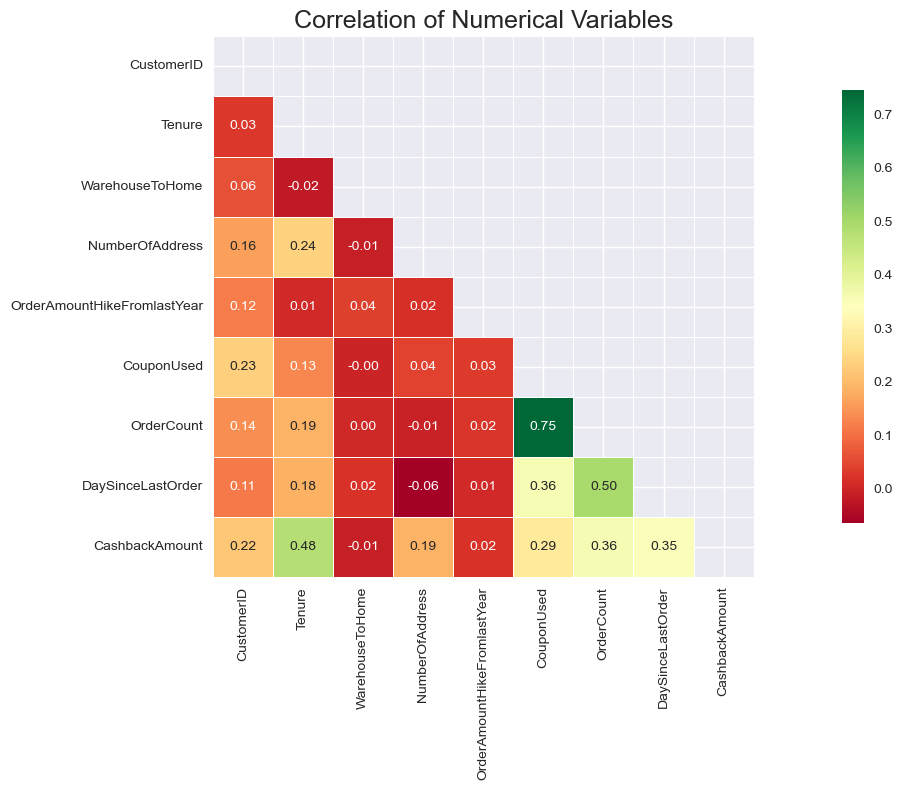

```python
# Correlation Matrix
f, ax = plt.subplots(figsize=[18, 8])

# Calculate the correlation matrix
corr_matrix = df[num_cols].corr()

# Generate a mask for the upper triangle
mask = np.triu(np.ones_like(corr_matrix, dtype=bool))

# Draw the heatmap
sns.heatmap(corr_matrix,
            mask=mask,  # Apply the mask to hide the upper triangle
            annot=True,
            fmt=".2f",
            ax=ax,
            cmap="RdYlGn",
            cbar_kws={"shrink": .8},  # Shrink the colorbar a bit
            square=True,  # Ensure the cells are square
            linewidths=0.5)  # Add thin lines between cells

ax.set_title("Correlation of Numerical Variables", fontsize=18)
plt.tight_layout()  # Adjust the layout to prevent cutoff
plt.show()
```

## Data processing and Feature Engineering

### Handling Missing values

```python
df.isnull().sum().sort_values(ascending=0)
```

```
DaySinceLastOrder              307
OrderAmountHikeFromlastYear    265
Tenure                         264
OrderCount                     258
CouponUsed                     256
HourSpendOnApp                 255
WarehouseToHome                251
CustomerID                       0
MaritalStatus                    0
Complain                         0
NumberOfAddress                  0
PreferedOrderCat                 0
SatisfactionScore                0
Churn                            0
NumberOfDeviceRegistered         0
Gender                           0
PreferredPaymentMode             0
CityTier                         0
PreferredLoginDevice             0
CashbackAmount                   0
dtype: int64
```

```python
def missing_values_table(dataframe, na_name=False):
    na_columns = [col for col in dataframe.columns if dataframe[col].isnull().sum() > 0]
    n_miss = dataframe[na_columns].isnull().sum().sort_values(ascending=False)
    ratio = (dataframe[na_columns].isnull().sum() / dataframe.shape[0] * 100).sort_values(ascending=False)
    missing_df = pd.concat([n_miss, np.round(ratio, 2)], axis=1, keys=['n_miss', 'ratio'])
    print(missing_df, end="\n")
    if na_name:
        return na_columns

na_columns = missing_values_table(df, na_name=True)
```

```
                             n_miss  ratio
DaySinceLastOrder               307  5.450
OrderAmountHikeFromlastYear     265  4.710
Tenure                          264  4.690
OrderCount                      258  4.580
CouponUsed                      256  4.550
HourSpendOnApp                  255  4.530
WarehouseToHome                 251  4.460
```

```python
df["DaySinceLastOrder"].fillna(df["DaySinceLastOrder"].median(), inplace=True)
df["OrderAmountHikeFromlastYear"].fillna(df["OrderAmountHikeFromlastYear"].median(), inplace=True)
df["Tenure"].fillna(df["Tenure"].median(), inplace=True)
df["OrderCount"].fillna(df["OrderCount"].median(), inplace=True)
df["CouponUsed"].fillna(df["CouponUsed"].median(), inplace=True)
df["HourSpendOnApp"].fillna(df["HourSpendOnApp"].median(), inplace=True)
df["WarehouseToHome"].fillna(df["WarehouseToHome"].median(), inplace=True)
```

```python
df.isnull().sum()
```

```
CustomerID                     0
Churn                          0
Tenure                         0
PreferredLoginDevice           0
CityTier                       0
WarehouseToHome                0
PreferredPaymentMode           0
Gender                         0
HourSpendOnApp                 0
NumberOfDeviceRegistered       0
PreferedOrderCat               0
SatisfactionScore              0
MaritalStatus                  0
NumberOfAddress                0
Complain                       0
OrderAmountHikeFromlastYear    0
CouponUsed                     0
OrderCount                     0
DaySinceLastOrder              0
CashbackAmount                 0
dtype: int64
```

### Outlier treatment

```python
def outlier_thresholds(dataframe, col_name, q1=0.05, q3=0.95):
    quartile1 = dataframe[col_name].quantile(q1)
    quartile3 = dataframe[col_name].quantile(q3)
    interquantile_range = quartile3 - quartile1
    up_limit = quartile3 + 1.5 * interquantile_range
    low_limit = quartile1 - 1.5 * interquantile_range
    return low_limit, up_limit


def check_outlier(dataframe, col_name):
    low_limit, up_limit = outlier_thresholds(dataframe, col_name)
    if dataframe[(dataframe[col_name] > up_limit) | (dataframe[col_name] < low_limit)].any(axis=None):
        return True
    else:
        return False

for col in num_cols:
    print(col, check_outlier(df, col))
```

```
CustomerID False
Tenure False
WarehouseToHome True
NumberOfAddress False
OrderAmountHikeFromlastYear False
CouponUsed True
OrderCount False
DaySinceLastOrder True
CashbackAmount False
```

```python
def replace_with_thresholds(dataframe, variable, q1=0.05, q3=0.95):
    low_limit, up_limit = outlier_thresholds(dataframe, variable, q1=0.05, q3=0.95)
    dataframe.loc[(dataframe[variable] < low_limit), variable] = low_limit
    dataframe.loc[(dataframe[variable] > up_limit), variable] = up_limit
```

```python
for col in num_cols:
    replace_with_thresholds(df,col)
```

```python
for col in num_cols:
    print(col, check_outlier(df, col))
```

```
CustomerID False
Tenure False
WarehouseToHome False
NumberOfAddress False
OrderAmountHikeFromlastYear False
CouponUsed False
OrderCount False
DaySinceLastOrder False
CashbackAmount False
```

### Encoding

```python
cat_cols, num_cols, cat_but_car = grab_col_names(df)
```

```
Observations: 5630
Variables: 20
cat_cols: 11
num_cols: 9
cat_but_car: 0
num_but_cat: 6
```

```python
from sklearn.preprocessing import LabelEncoder

def label_encoder(dataframe, binary_col):
    labelencoder = LabelEncoder()
    dataframe[binary_col] = labelencoder.fit_transform(dataframe[binary_col])
    return dataframe


binary_cols = [col for col in df.columns if df[col].dtypes == "O" and df[col].nunique() == 2]
binary_cols

cat_cols = [col for col in cat_cols if col not in binary_cols and col not in ["Churn"]]

for col in binary_cols:
    df = label_encoder(df, col)
```

```python
def one_hot_encoder(dataframe, categorical_cols, drop_first=False):
    dataframe = pd.get_dummies(dataframe, columns=categorical_cols, drop_first=drop_first)
    return dataframe


df = one_hot_encoder(df, cat_cols, drop_first=True)
```

```python
df.head()
```

|  | CustomerID | Churn | Tenure | WarehouseToHome | Gender | NumberOfAddress | OrderAmountHikeFromlastYear | CouponUsed | OrderCount | DaySinceLastOrder | CashbackAmount | PreferredLoginDevice_Mobile Phone | PreferredLoginDevice_Phone | PreferredPaymentMode_COD | PreferredPaymentMode_Cash on Delivery | PreferredPaymentMode_Credit Card | PreferredPaymentMode_Debit Card | PreferredPaymentMode_E wallet | PreferredPaymentMode_UPI | PreferedOrderCat_Grocery | PreferedOrderCat_Laptop & Accessory | PreferedOrderCat_Mobile | PreferedOrderCat_Mobile Phone | PreferedOrderCat_Others | MaritalStatus_Married | MaritalStatus_Single | CityTier_2 | CityTier_3 | HourSpendOnApp_1.0 | … |
| --- | --- | --- | --- | --- | --- | --- | --- | --- | --- | --- | --- | --- | --- | --- | --- | --- | --- | --- | --- | --- | --- | --- | --- | --- | --- | --- | --- | --- | --- | --- |
| 0 | 50001.000 | 1 | 4.000 | 6.000 | 0 | 9.000 | 11.000 | 1.000 | 1.000 | 5.000 | 160.000 | True | False | False | False | False | True | False | False | False | True | False | False | False | False | True | False | True | False | … |
| 1 | 50002.000 | 1 | 9.000 | 8.000 | 1 | 7.000 | 15.000 | 0.000 | 1.000 | 0.000 | 121.000 | False | True | False | False | False | False | False | True | False | False | True | False | False | False | True | False | False | False | … |
| 2 | 50003.000 | 1 | 9.000 | 30.000 | 1 | 6.000 | 14.000 | 0.000 | 1.000 | 3.000 | 120.000 | False | True | False | False | False | True | False | False | False | False | True | False | False | False | True | False | False | False | … |
| 3 | 50004.000 | 1 | 0.000 | 15.000 | 1 | 8.000 | 23.000 | 0.000 | 1.000 | 3.000 | 134.000 | False | True | False | False | False | True | False | False | False | True | False | False | False | False | True | False | True | False | … |
| 4 | 50005.000 | 1 | 0.000 | 12.000 | 1 | 3.000 | 11.000 | 1.000 | 1.000 | 3.000 | 130.000 | False | True | False | False | False | False | False | False | False | False | True | False | False | False | True | False | False | False | … |

```python
print(df.shape)
```

```
(5630, 43)
```

## Discussion

*[Ongoing update]*